# PCA for Correcting for Population Structure in a GWAS

# On the cluster

## Prep VCFs for the PCA

This is done on the cluster (code blocks not run when Rmd is rendered).

```bash
mkdir -p intermediates/203
```

We include just the springs and falls, since they are the ones going into the GWAS.

Get a file of spring and fall fishIDs. We will extract their read depths from the VCF and use my single-read-sampling package, ’srsStuff" to do a PCA.

```bash
awk -F"," '$NF=="Fall" || $NF == "Spring" {print $1}' data/wgs-chinook-samples.csv > intermediates/203/spring_falls.txt
```

We will do the PCA just with the assembled chromosomes. That is still a lot of markers…about 8 million, I think.

```bash
# filter all the vcfs down to new ones for each chromosome
ls -l chinook_WGS_processed/NC_037*.vcf.gz | \
  awk 'BEGIN {OFS="\t"; print "index", "file"} {print ++n, $NF }' > intermediates/203/vfiles.txt


sbatch ./script/203-bcftools-array.sh

# catenate all those into a single bcf (which is 2.1 Gb zipped) and index it
bcftools concat -o intermediates/203/all-chroms-filtered.bcf -Ob intermediates/203/filtered_NC_037*.bcf
bcftools index intermediates/203/all-chroms-filtered.bcf

# show some stats about that
bcftools stats intermediates/203/all-chroms-filtered.bcf > intermediates/203/stats-all-chroms-filtered.txt
```

Here are the stats:

```
# SN    [2]id   [3]key  [4]value
SN      0       number of samples:      128
SN      0       number of records:      5939644
SN      0       number of no-ALTs:      0
SN      0       number of SNPs: 4840746
SN      0       number of MNPs: 0
SN      0       number of indels:       1098898
SN      0       number of others:       0
SN      0       number of multiallelic sites:   0
SN      0       number of multiallelic SNP sites:       0
```

Now, we already know that the 14 individuals we dropped from Salmon River have such low coverge that their covariance values, when they occur together in pairs, have high variance and they end up getting pulled apart on PC-2, which is clearly spurious. So, we will just drop them for both the PCA and the GWAS.

The individuals with average read depth of genotypes < 0.45X are obtained from 004, but we will just redo the calculation here and put the 14 bad ones into `stored_results`.

```r
library(vcfR)
library(tidyverse)
rfi <- read.vcfR("data/greb1l-ish-region.vcf.gz")
rfi_depths <- vcfR2tidy(rfi)$gt %>%
  mutate(DP = ifelse(is.na(gt_DP), 0, gt_DP))

dp_means <- rfi_depths %>%
  group_by(Indiv) %>%
  summarise(mean_depth = mean(DP)) %>%
  arrange(mean_depth)
dp_means

# so the ones we want to drop are the first 14 of those:
droppers <- dp_means %>% slice(1:14) %>% pull(Indiv)
cat(droppers, sep = "\n")
```

Those go into `stored_results/203/low-depth-14-to-drop.txt`.

Now, we use bcftools to drop those 14 from the file:

```bash
bcftools view -S ^stored_results/203/low-depth-14-to-drop.txt \
  intermediates/203/all-chroms-filtered.bcf \
  -Ob > intermediates/203/all-chroms-14-dropped.bcf
```

Then we are going to extract the read depths:

```bash
time bcftools query -f '%CHROM\t%POS[\t%AD]\n' intermediates/203/all-chroms-14-dropped.bcf  > intermediates/203/ac-114-fish-allele-depths.txt

# that is pretty quick
real    1m15.558s
user    1m11.482s
sys     0m3.225s

# get the names of the fish in that file, in the order they are in
bcftools query -l intermediates/203/all-chroms-14-dropped.bcf > intermediates/203/114-fish-names.txt
```

## Do the PCA

Get srsStuff set up and compute the covariance matrix

```r
# I installed it with a temp OAuth token:
# devtools::install_github("eriqande/srsStuff", auth_token = "3a04dd77d331xxx....")
library(tidyverse)
library(srsStuff)

# compute the covariance matrix
system.time(
  covar_114 <- srs_covar("intermediates/203/ac-114-fish-allele-depths.txt",
    sample_names = read_lines("intermediates/203/114-fish-names.txt"))
)

# now, we are going to write that out to stored results so that
# it is easy to have and manipulate to make figures on my laptop.
write_rds(covar_114, path = "stored_results/203/covar-matrix-etc-114-spring-fall-fish.rds", compress = "xz")
```

# Working from the laptop

R code below here is evaluated when the notebook is rendered.

Now prepare some stuff for processing and plotting things:

```r
library(tidyverse)

meta <- read_csv("data/wgs-chinook-samples.csv") %>%
  mutate(pop = str_replace_all(Population, "Fall|Spring|Winter", "") %>% str_trim()) %>%
  select(-Population) %>%
  mutate(
    Population = recode(
      pop,
      "Salmon River" =  "Salmon R.",
      "Feather River Hatchery" =  "Feather R.H.",
      "Trinity River Hatchery" =  "Trinity R.H",
      "San Joaquin River" =  "San Joaquin R.",
      "Coleman Hatchery Late" =  "Coleman H.",
      "Sacramento River" =  "Sacramento R. Winter Run",
      "Butte Creek" =  "Butte Ck."
    ),
    Ecotype = recode(
      run_type,
      "Fall" =  "Fall Run",
      "Spring" =  "Spring Run",
      "Late Fall" =  "Late Fall Run",
      "Winter" =  "Winter Run",
    )
  ) %>%
  mutate( # make a factor to be able to order the populations a little better
    Population_f = factor(
      Population,
      levels = c(
        "Sacramento R. Winter Run",
        "San Joaquin R.",
        "Butte Ck.",
        "Coleman H.",
        "Feather R.H.",
        "Salmon R.",
        "Trinity R.H"
      )
    )
  )

# and make sure that our colors or here
pca_colors <- c(
  `Salmon R.` = "#bae4b3",
  `Feather R.H.` = "#fee5d9",
  `Trinity R.H` = "#238b45",
  `San Joaquin R.` = "#fb6a4a",
  `Coleman H.` = "#fcbba1",
  `Sacramento R. Winter Run` = "#a50f15",
  `Butte Ck.` = "#fc9272"
)
# and set our shape values
pca_shapes <- c(
  `Fall Run` = 21,
  `Spring Run` = 24,
  `Late Fall Run` = 25,
  `Winter Run` = 23
)

# function
prep_output <- function(A) {

  # first for each individual i, get the number of sites at which
  # that individual had a read and also another individual, j, averaged
  # over all j.  This tells us on average how many markers went into
  # compute the covariance for each individual.
  m <- A$M
  diag(m) <- 0
  ave_sites <- tibble(
    vcf_name = A$sample_names,
    ave_sites = rowMeans(m) * ncol(m) / (ncol(m) - 1)
  )

  # do the whole eigendecomposition on the standard covariance matrix.
  eig <- eigen(A$Cov)
  colnames(eig$vectors) <- sprintf("PC-%02d", 1:ncol(eig$vectors))


  pca_tib <- as_tibble(eig$vectors[, 1:6]) %>%
    mutate(vcf_name = A$sample_names) %>%
    select(vcf_name, everything())

  pca_long <- pca_tib %>%
    tidyr::gather(., key = "PC", "val", -vcf_name)

  # then expand a grid of the possible comparisons (ordered)
  pca_pairs <- expand.grid(
    vcf_name = pca_tib$vcf_name,
    PCx = sprintf("PC-%02d", 1:6),
    PCy = sprintf("PC-%02d", 1:6),
    stringsAsFactors = FALSE
  ) %>%
    tibble::as_tibble() %>%
    dplyr::left_join(., pca_long, by = c("vcf_name", "PCx" = "PC")) %>%
    dplyr::rename(val_x = val) %>%
    dplyr::left_join(pca_long, by = c("vcf_name", "PCy" = "PC")) %>%
    dplyr::rename(val_y = val) %>%
    left_join(ave_sites, by = "vcf_name") %>% # and here, join on some meta data
    left_join(meta, by = "vcf_name")


  # and now we are going to the the same sort of thing, but on the covariance
  # matrix computed by the corrlations estimated a la Weir and Goudet
  WaG <- (A$IBS - A$Mt_S) / (1 - A$Mt_S)
  eig <- eigen(WaG)
  colnames(eig$vectors) <- sprintf("PC-%02d", 1:ncol(eig$vectors))


  pca_tib <- as_tibble(eig$vectors[, 1:6]) %>%
    mutate(vcf_name = A$sample_names) %>%
    select(vcf_name, everything())

  pca_long <- pca_tib %>%
    tidyr::gather(., key = "PC", "val", -vcf_name)

  pcp <- expand.grid(
    vcf_name = pca_tib$vcf_name,
    PCx = sprintf("PC-%02d", 1:6),
    PCy = sprintf("PC-%02d", 1:6),
    stringsAsFactors = FALSE
  ) %>%
    tibble::as_tibble() %>%
    dplyr::left_join(., pca_long, by = c("vcf_name", "PCx" = "PC")) %>%
    dplyr::rename(WaG_x = val) %>%
    dplyr::left_join(pca_long, by = c("vcf_name", "PCy" = "PC")) %>%
    dplyr::rename(WaG_y = val)

  # then join those both and return them
  left_join(pcp, pca_pairs,
    by = c("vcf_name", "PCx", "PCy")
  )
}
```

Then use that to make a figure:

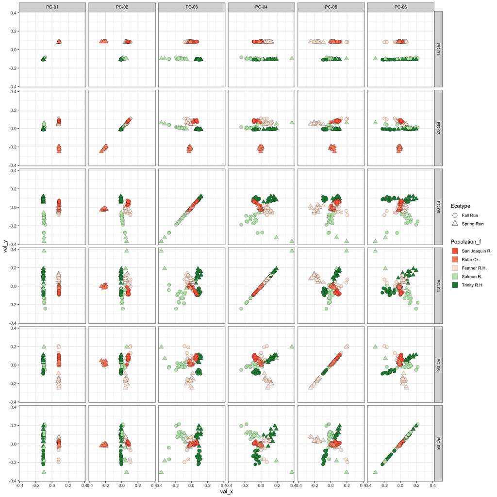

```r
covar_114 <- read_rds("stored_results/203/covar-matrix-etc-114-spring-fall-fish.rds")
allf <- prep_output(covar_114)

bp <- ggplot(allf, aes(x = val_x, y = val_y, fill = Population_f, shape = Ecotype)) +
  facet_grid(PCy ~ PCx) +
  geom_point(size = 3, stroke = 0.15) +
  scale_fill_manual(values = pca_colors) +
  scale_shape_manual(values = pca_shapes) +
  theme_bw() +
  guides(
    fill = guide_legend(override.aes = list(shape = 22, stroke = 0.1, size = 6)),
    shape = guide_legend(override.aes = list(stroke = 0.35, size = 4))
  )

dir.create("outputs/203", recursive = TRUE, showWarnings = FALSE)
ggsave(bp, filename = "outputs/203/spring-fall-pca.pdf", width = 20, height = 20)

# and print it here
bp
```

It is clear that the first PC separates Klamath from Sacramento basin. PC-2 separates Butte Creek from the rest of the Sacramento basin. PC-3 separates Trinity River from Salmon River fish, and then on PC-4 we start seeing spring and fall in the Trinity separating.

Now, at the end, we will save the principal components in a text file for use as covariates in a GWAS with ANGSD.

```r
eig <- eigen(covar_114$Cov)
eigenvectors <- eig$vectors
rownames(eigenvectors) <- covar_114$sample_names
colnames(eigenvectors) <- sprintf("PC-%02d", 1:ncol(eig$vectors))
write.table(eigenvectors, file = "stored_results/203/eigenvectors.tsv", quote = FALSE, row.names = TRUE, col.names = TRUE)
```

# Running Time

Running the code and rendering this notebook required approximately this much time on a Mac laptop of middling speed:

```r
Sys.time() - start_time
```

```
## Time difference of 4.239197 secs
```